# Assignment Part Il - Jupyter Notebook

### Task 3

Plot a visualization to show the number of listings for each `room_type`

Which `room_type` has the highest number of listings?

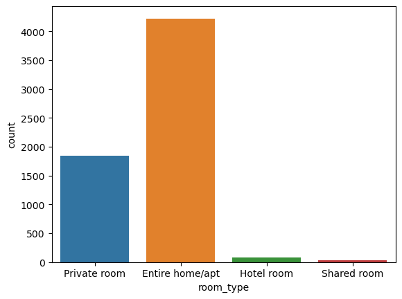

```python
sns.countplot(data=df, x='room_type')
plt.show()
```

**Observation** - We can easily compair and see that Entire home type have the highest number of listing.

### Task 4

You want to observe the relationship between the reviews(given by `number_of_reviews`) and the ratings received (`review_scores_rating`) by different AirBnB listings.

For this, plot both a scatterplot and a jointplot. What can you say about the relationship between ratings and reviews?

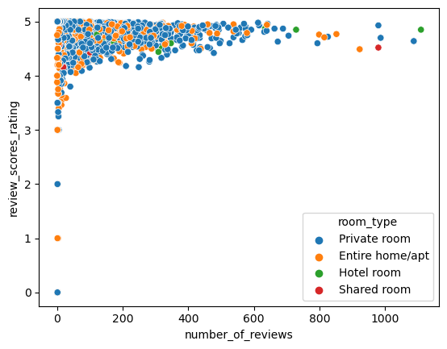

```python
##Write your code here for scatterplot
sns.scatterplot(data=df,x="number_of_reviews",y="review_scores_rating",hue="room_type")
plt.show()
```

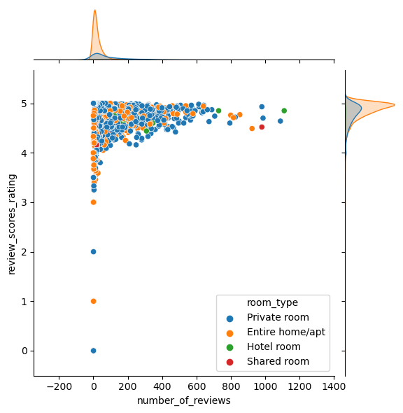

```python
##Write your code here for jointplot
sns.jointplot(data=df,x="number_of_reviews",y="review_scores_rating",hue="room_type")
plt.show()
```

### Task 5

AirBnB has been adding quite a few listings in the city of Amseterdam since they started operating in 2008. Plot a lineplot to observe how the average `review_scores_rating` has changed across the different years (use `host_since_Year` column) AirBnB has been operating in the city.

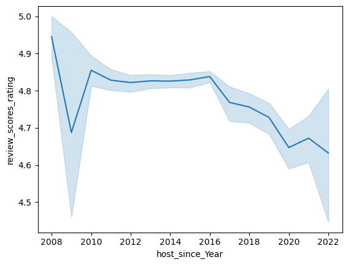

```python
### Write your code for lineplot here
sns.lineplot(x="host_since_Year",y="review_scores_rating",data=df)
plt.show()
```